# **results: Amsterdam subgraphs**

We start by extracting the phylogenetic subgraphs that are associated with viral spread in Amsterdam. If we interpret each subgraph as a distinct transmission chain in Amsterdam, (which may be partially observed due to incomplete sequence sampling), we can explore patterns within transmission chains.

```r
roadmap.200203.phyloscanner.get.dated.subgraphs<- function()
{
  require(data.table)
  require(phangorn)
  require(ggplot2)
  require(reshape)
  require(phyloscannerR)

  # working directory with phyloscanner output
  source('/rdsgpfs/general/project/ratmann_roadmap_data_analysis/live/R/bigphylo functions.R')

  home <- '/Users/alexb/Documents/Roadmap/Data/SHM_1902_ROADMAP_191223/analysis_200514_MoroccoTurkey_Sep'
  home <- '/rds/general/project/ratmann_roadmap_data_analysis/live/analysis_200514_MoroccoTurkey_Sep'
  indir.phsc    <- file.path(home,'phyloscanner_dated')
  outdir <- file.path(home,'subgraphs_dated')
  infiles       <- data.table(F=list.files(indir.phsc, pattern='_annotated_dated_tree.rda$', full.names=TRUE, recursive=TRUE))
  infiles[, SELECT:= gsub('^.*_rerooted_([A-Za-z0-9]+)_.*$','\\1',basename(F))]
  #infiles <- subset(infiles, grepl('subtype_B',F))

  # extract subgraphs of dated trees
  for(i in seq_len(nrow(infiles)))
    {
    #i<- 21
    cat('process', i,'\n')
    infile <- infiles[i, F]
    host <- infiles[i,SELECT]
    load(infile)
    mrcas <- which( attr(ph, 'SUBGRAPH_MRCA') )
    #   some of the tips states are "unknown" and this clashes internally with the NA state, so we need to take some extra care
    #   this is not a problem because the "unknown" and NA state mean the same thing
    attr(ph, 'INDIVIDUAL') <- as.character(attr(ph, 'INDIVIDUAL'))
    attr(ph, 'INDIVIDUAL')[is.na(attr(ph, 'INDIVIDUAL'))] <- 'Unknown'
    mrcas <- mrcas[ attr(ph, 'INDIVIDUAL')[mrcas]==host ]
    #for (i in seq_len(length(mrcas))){
    #  print(i)
    #  subgraphs <- extract.subgraph(ph, mrcas[i])
    #}
    stopifnot( !any(is.na(mrcas)) )
    # check that tree is of class simmap
    stopifnot( any(attr(ph,'class')=='simmap') )
    # extract subgraphs
    subgraphs <- lapply(mrcas, function(mrca) extract.subgraph(ph, mrca))
    # save
    outfile <- gsub('_annotated_dated_tree',paste0('_datedsubgraphs_',host),basename(infile))
    outfile <- file.path(outdir,outfile)
    save(subgraphs, file=outfile)
  }
}

### Read phylogenetic subgraphs
require(data.table)
require(phangorn)
require(ggplot2)
require(reshape)

#   working directory with phyloscanner output
home <- '/Users/alexb/Documents/Roadmap/Data/SHM_1902_ROADMAP_191223'
home <- '/rds/general/project/ratmann_roadmap_data_analysis/live'
indir.phsc  <- file.path(home,'analysis_200514_MoroccoTurkey_Sep','subgraphs_dated')

#   extract subgraph taxa
infiles <- data.table(F=list.files(indir.phsc, pattern='rda$', full.names=TRUE, recursive=TRUE))
infiles <- subset(infiles, grepl('datedsubgraphs',F))
#   SELECT defines if Ams, AmsHSX, AmsMSM
infiles[, SELECT:= gsub('^(.*)subgraphs_([A-Za-z]+).rda','\\2',basename(F))]
#   for subtype B, I ran separate analyses based on very large subtrees for comp efficiency
#   ST stores the subtype, and ST_CLADE the large subtree
infiles[, ST:= gsub('^.*subtype_([^_]+)_.*\\.rda','\\1',basename(F))]
# For B only
infiles[, ST_CLADE:= as.integer(gsub('[^c]*c([0-9]+)','\\1',ST))]
infiles[, ST:= gsub('([^c]*)c([0-9]+)','\\1',ST)]
#   ID of bootstrap replicate, 000 for analysis on real alignment
infiles[, REP:= gsub('^.*wOutgroup_([0-9]+)_.*\\.rda','\\1',basename(F))]
dsubgraphtaxa <- infiles[, {
  #i<- 1
  #infile <- infiles[i, F]
  infile <- F
  cat('Process',infile,'\n')
  load(infile)
    if(length(subgraphs)==1){
        subgraph.names <- rep(subgraphs[[1]]$subgraph.name, length(subgraphs[[1]]$tip.label))
        subgraph.taxa <- subgraphs[[1]]$tip.label
  }  else{
    subgraph.names <- unlist(sapply( subgraphs, function(subgraph)  rep(subgraph$subgraph.name, length(subgraph$tip.label)) ))
    subgraph.taxa <- unlist(sapply( subgraphs, function(subgraph)  subgraph$tip.label))
  }
  list(NAME=subgraph.names,
      TAXA= subgraph.taxa
  )
}, by=c('ST','ST_CLADE','REP','SELECT')]
#   add meta data from taxa names
regex.tip.label <- '^([A-Za-z]+)_+([0-9]+)_([0-9]+)_([a-zA-Z]+)_([a-zA-Z]+)_([a-zA-Z]+)-([a-zA-Z]+)_([a-zA-Z_]+)_([0-9]+)-([0-9-]+)-([0-9-]+)_([0-9]+)$'
dsubgraphtaxa[, ID:= as.numeric(gsub(regex.tip.label,'\\3',TAXA))]
dsubgraphtaxa[, SEQ_YEAR:= as.numeric(gsub(regex.tip.label,'\\9',TAXA))]
dsubgraphtaxa[, FULL_NAME:= paste0(ST,'_',REP,'_',SELECT,'_',NAME)]

#   add meta data from pre-processed persons file
infile.meta <- file.path(home,'analysis_200514_MoroccoTurkey_Sep','misc','200327_sequence_labels.rda')

load(infile.meta)
dind <- as.data.table(dind)
setnames(dind, c('PATIENT','BIRTH_Y','BIRTH_CNTRY'), c('ID','BIRTH_YEAR','BIRTH_COUNTRY'))
tmp <- subset(dind, select=c(ID,BIRTH_YEAR,BIRTH_COUNTRY,LOC_BIRTH,CITY,TRANSM,GENDER))
set(tmp, NULL, 'BIRTH_YEAR', tmp[, as.numeric(BIRTH_YEAR)])
dsubgraphtaxa <- merge(dsubgraphtaxa,tmp,by='ID')
dsubgraphtaxa[, AGE2020:= cut(2020-BIRTH_YEAR, breaks=c(-Inf,20,25,30,35,40,45,50,55,60,Inf))]

dsubgraphsize <- dsubgraphtaxa[, list(SIZE=length(ID)), by=c('ST','REP','SELECT','NAME')]
dsubgraphsize[, SINGLETON:= as.character(factor(SIZE==1, levels=c(TRUE,FALSE), labels=c('subgraph size 1','subgraph size >1')))]
ggplot(subset(dsubgraphsize, SELECT!='Ams'), aes(x=SIZE, fill=ST)) +
  geom_bar() +
  xlim(0,30) +
  facet_grid(SELECT~.) +
  labs(x='\nsize of phylogenetic subgraphs attributed to Amsterdam')
outfile <- file.path(indir.phsc,'dist_subgraph_sizes.pdf')
ggsave(outfile)

# Size of subgraphs for all STs/Reps by HSX/MSM
dsubgraphsize <- dsubgraphtaxa[, list(SIZE=length(ID)), by=c('ST','REP','SELECT','NAME')]
dsubgraphsizefreq <- dsubgraphsize[, list(N=length(NAME)), by=c('SELECT','SIZE')]
dsubgraphsizefreq <- dsubgraphsizefreq[SELECT!='Ams',]
freqs <- dsubgraphsizefreq[order(SELECT,SIZE),]
freqshsx <- freqs[SELECT=='AmsHSX',]
freqsmsm <- freqs[SELECT=='AmsMSM',]
listhsx <- data.frame(SELECT=rep('AmsHSX',max(freqshsx$SIZE)),SIZE=1:max(freqshsx$SIZE))
listmsm <- data.frame(SELECT=rep('AmsMSM',max(freqsmsm$SIZE)),SIZE=1:max(freqsmsm$SIZE))
freqshsx <- merge(listhsx,freqshsx,by=c("SELECT","SIZE"),all=TRUE)
freqshsx$N[is.na(freqshsx$N)] <- 0
freqsmsm <- merge(listmsm,freqsmsm,by=c("SELECT","SIZE"),all=TRUE)
freqsmsm$N[is.na(freqsmsm$N)] <- 0
outfilehsx  <- file.path(indir.phsc,'subgraphsizes_hsx.csv')
outfilemsm  <- file.path(indir.phsc,'subgraphsizes_msm.csv')
write.csv(freqshsx,file=outfilehsx)
write.csv(freqsmsm,file=outfilemsm)
```

```r
# Sample size for phylodynamic analysis of HIV spread in Amsterdam
#   number of individuals in subgraphs of size == 1 or size > 1
dsubgraphind <- dsubgraphsize[, list(N_INDIVIDUALS=sum(SIZE)), by=c('REP','ST','SELECT','SINGLETON')]
dsubgraphind <- dcast.data.table(dsubgraphind, REP+ST+SINGLETON~SELECT,value.var='N_INDIVIDUALS')
dsubgraphind

dsubgraphsize$ST2 <- 'Non-B'
dsubgraphsize$ST2[dsubgraphsize$ST=='B'] <- 'B'
dsubgraphind2 <- dsubgraphsize[, list(N_INDIVIDUALS=sum(SIZE)), by=c('ST2','SELECT','SINGLETON')]

# Proportion of subclades size 1 vs. >1
dsubgraphsin <- dsubgraphsize[, list(N_SINGLETONCLADES=length(NAME)), by=c('ST2','SELECT','SINGLETON')]

# Empirical analysis on group-mixing within subgraphs
#   number of individuals in subgraphs of size == 1 or size > 1
tmp <- subset(dsubgraphsize, SIZE>1, c(ST, REP, SELECT, NAME))
dsubgraphtaxa2 <- merge(dsubgraphtaxa, tmp, by=c('ST','REP','SELECT','NAME'))

# Place of birth
dsubgraphtaxa2[, DUMMY:= as.character(factor(BIRTH_COUNTRY=='Netherlands',levels=c(TRUE,FALSE),labels=c('Netherlands','Other')))]
dcnt <- dsubgraphtaxa2[, list(N= length(ID)), by=c('FULL_NAME','REP','SELECT','ST','DUMMY')]
tmp <- dsubgraphtaxa2[, list(TOTAL= length(ID)), by=c('FULL_NAME','SELECT','ST')]
dcnt <- merge(dcnt, tmp, by=c('FULL_NAME','SELECT','ST'))
ggplot(subset(dcnt, SELECT!='Ams'), aes(x=FULL_NAME, y=N, fill=DUMMY)) +
  geom_bar(stat='identity') +
  labs(y='#individuals',x='phylo subgraphs',fill='birth place') +
  theme(axis.text.x=element_blank(), axis.ticks.x=element_blank()) +
  facet_grid(SELECT~ST, scale='free_x', space='free_x')
outfile <- file.path(indir.phsc,'place_birth.pdf')
ggsave(outfile)

tmp <- dcnt[, list(R= sum( (N/TOTAL)^2), PMAX= max(N/TOTAL) ), by=c('FULL_NAME','SELECT','ST')]
tmp[, list(R_AVG=mean(R), PMAX_AVG=mean(PMAX)), by=c('SELECT')]

# Show for all subclades for subtype X, how many/what proportion is >75% NL/>75% other and otherwise mixed?
dcnt$PROP <- dcnt$N/dcnt$TOTAL
bp <- dcnt[, list(N75= length(FULL_NAME[PROP>=0.75])), by=c('SELECT','REP','ST','DUMMY')]
#tmp <- dsubgraphtaxa2[, list(TOTAL= length(ID)), by=c('SELECT','ST')]
nsubgraphs <- dsubgraphtaxa2[, list(SIZE=length(unique(NAME))), by=c('REP','ST','SELECT')]
bp <- merge(bp,nsubgraphs, by=c('REP','ST','SELECT'))
mixed <- bp[, list(Mixed= SIZE-sum(N75)), by=c('REP','ST','SELECT')]
bp <- spread(bp, DUMMY, N75)
bp <- merge(bp,mixed,by=c('REP','ST','SELECT'))
bp <- unique(bp)
bp <- melt(bp, id.vars=c('REP', 'ST', 'SELECT', 'SIZE'))
#bp <- bp[order('REP','ST','SELECT'),]

bp$bpp <- factor(bp$variable, levels=c('Netherlands','Other','Mixed'),labels=c(">75% NL", ">75% MW-MB", "Mixed"))

nonbl <- ggplot(subset(bp, SELECT!='Ams' & ST!='B'), aes(x=ST, y=value, fill=bpp)) +
  geom_bar(stat='identity') +
  labs(y='#subgraphs',x='subtype',fill='birth place') +
  theme(axis.ticks.x=element_blank()) +
  facet_grid(SELECT~., scale='free_x', space='free_x')

legend <- get_legend(nonbl)

nonb <- ggplot(subset(bp, SELECT!='Ams' & ST!='B'), aes(x=ST, y=value, fill=bpp)) +
  geom_bar(stat='identity') +
  labs(y='#subgraphs',x='subtype',fill='birth place') +
  theme(axis.ticks.x=element_blank(),legend.position="none") +
  facet_grid(SELECT~., scale='free_x', space='free_x')

b <- ggplot(subset(bp, SELECT!='Ams' & ST=='B'), aes(x=ST, y=value, fill=bpp)) +
  geom_bar(stat='identity') +
  labs(y='',x='subtype',fill='birth place') +
  theme(axis.ticks.x=element_blank(),legend.position="none") +
  facet_grid(SELECT~., scale='free_x', space='free_x')

# Combine the graphs
outfile <- file.path(outpath,"mixing_bp_BnonB.pdf")
bp_bnonb <-   grid.arrange(nonb, b,
                      legend,
                      ncol = 3, widths=c(3.5, 1.5, 1.5))
ggsave(file=outfile, bp_bnonb, w=8, h=6)

# All STs together
ggplot(subset(bp, SELECT!='Ams'), aes(x=ST, fill=bpp)) +
  geom_bar(position = "fill") +
  labs(y='#subgraphs',x='subtype',fill='birth place') +
  theme(axis.ticks.x=element_blank()) +
facet_grid(SELECT~., scale='free_x', space='free_x')
outfile <- file.path(indir.phsc,'place_birth_75pct.pdf')
ggsave(outfile)

# Age group
dsubgraphtaxa2[, DUMMY:= AGE2020]
dcnt <- dsubgraphtaxa2[, list(N= length(ID)), by=c('FULL_NAME','SELECT','ST','DUMMY')]
tmp <- dsubgraphtaxa2[, list(TOTAL= length(ID)), by=c('FULL_NAME','SELECT','ST')]
dcnt <- merge(dcnt, tmp, by=c('FULL_NAME','SELECT','ST'))
ggplot(subset(dcnt, SELECT!='Ams'), aes(x=FULL_NAME, y=N, fill=DUMMY)) +
  geom_bar(stat='identity') +
  labs(y='#individuals',x='phylo subgraphs',fill='age in 2020') +
  theme(axis.text.x=element_blank(), axis.ticks.x=element_blank()) +
  facet_grid(SELECT~ST, scale='free_x', space='free_x')
outfile <- file.path(indir.phsc,'age_group.pdf')
ggsave(outfile)

tmp <- dcnt[, list(R= sum( (N/TOTAL)^2), PMAX= max(N/TOTAL) ), by=c('FULL_NAME','SELECT','ST')]
tmp[, list(R_AVG=mean(R), PMAX_AVG=mean(PMAX)), by=c('SELECT')]

# Transmission groups


# Geographic region of birth
dsubgraphtaxa2$LOC_BIRTH[dsubgraphtaxa2$BIRTH_COUNTRY=='Netherlands'] <- dsubgraphtaxa2$BIRTH_COUNTRY[dsubgraphtaxa2$BIRTH_COUNTRY=='Netherlands']
dsubgraphtaxa2[, DUMMY:= factor(LOC_BIRTH, levels=c('Netherlands','WEurope','EEurope','Africa','Asia','LaAmCarr','NorthAm','Oceania','Unknown'),labels=c('Netherlands','WEurope','EEurope','Africa','Asia','LaAmCarr','NorthAm','Oceania','Unknown'))]
dcnt <- dsubgraphtaxa2[, list(N= length(ID)), by=c('FULL_NAME','REP','SELECT','ST','DUMMY')]
tmp <- dsubgraphtaxa2[, list(TOTAL= length(ID)), by=c('FULL_NAME','REP','SELECT','ST')]
dcnt <- merge(dcnt, tmp, by=c('FULL_NAME','REP','SELECT','ST'))
ggplot(subset(dcnt, SELECT!='Ams'), aes(x=FULL_NAME, y=N, fill=DUMMY)) +
  geom_bar(stat='identity') +
  labs(y='#individuals',x='phylo subgraphs',fill='birth place') +
  theme(axis.text.x=element_blank(), axis.ticks.x=element_blank()) +
  facet_grid(SELECT~ST, scale='free_x', space='free_x')
outfile <- file.path(indir.phsc,'region_birth.pdf')
ggsave(outfile)

tmp <- dcnt[, list(R= sum( (N/TOTAL)^2), PMAX= max(N/TOTAL) ), by=c('FULL_NAME','SELECT','ST')]
tmp[, list(R_AVG=mean(R), PMAX_AVG=mean(PMAX)), by=c('SELECT')]
```

```r
# Show for all subclades for subtype X, how many/what proportion is >75% NL/>75% other and otherwise mixed?
dcnt$PROP <- dcnt$N/dcnt$TOTAL
bp <- dcnt[, list(N75= length(FULL_NAME[PROP>=0.75])), by=c('SELECT','REP','ST','DUMMY')]
nsubgraphs <- dsubgraphtaxa2[, list(SIZE=length(unique(NAME))), by=c('REP','ST','SELECT')]
bp <- merge(bp,nsubgraphs, by=c('REP','ST','SELECT'))
mixed <- bp[, list(Mixed= SIZE-sum(N75)), by=c('REP','ST','SELECT')]
bp <- spread(bp, DUMMY, N75)
bp <- merge(bp,mixed,by=c('REP','ST','SELECT'))
bp <- unique(bp)
bp <- melt(bp, id.vars=c('REP', 'ST', 'SELECT', 'SIZE'))

bp$bpp <- factor(bp$variable, levels=c('Netherlands','WEurope','EEurope','Africa','Asia','LaAmCarr','NorthAm','Oceania','Unknown','Mixed'),labels=c('>75% Netherlands','>75% WEurope','>75% EEurope','>75% Africa','>75% Asia','>75% LaAmCarr','>75% NorthAm','>75% Oceania','>75% Unknown','Mixed'))

ggplot(subset(bp, SELECT!='Ams'), aes(x=ST, y=value, fill=bpp)) +
  geom_bar(stat='identity') +
  labs(y='#subgraphs',x='subtype',fill='birth place') +
  theme(axis.ticks.x=element_blank()) +
  facet_grid(SELECT~., scale='free_x', space='free_x')
outfile <- file.path(indir.phsc,'region_birth_75pct.pdf')
ggsave(outfile)

nonbl <-  ggplot(subset(bp, SELECT!='Ams' & ST!='B'), aes(x=ST, y=value, fill=bpp)) +
  geom_bar(stat='identity') +
  labs(y='#subgraphs',x='subtype',fill='birth place') +
  theme(axis.ticks.x=element_blank()) +
  facet_grid(SELECT~., scale='free_x', space='free_x')

legend <- get_legend(nonbl)

nonb <- ggplot(subset(bp, SELECT!='Ams' & ST!='B'), aes(x=ST, y=value, fill=bpp)) +
  geom_bar(stat='identity') +
  labs(y='#subgraphs',x='subtype',fill='birth place') +
  theme(axis.ticks.x=element_blank(),legend.position="none") +
  facet_grid(SELECT~., scale='free_x', space='free_x')

b <-   ggplot(subset(bp, SELECT!='Ams' & ST=='B'), aes(x=ST, y=value, fill=bpp)) +
  geom_bar(stat='identity') +
  labs(y='',x='subtype',fill='birth place') +
  theme(axis.ticks.x=element_blank(),legend.position="none") +
  facet_grid(SELECT~., scale='free_x', space='free_x')

# Combine the graphs
outfile <- file.path(outpath,"mixing_bp_reg_BnonB.pdf")
bp_bnonb <-   grid.arrange(nonb, b,
                           legend,
                           ncol = 3, widths=c(3.5, 1.5, 1.5))
ggsave(file=outfile, bp_bnonb, w=8, h=6)
```

Just a few notes: a large fraction of the subgraphs consist of just one sequence. These subgraphs don’t contain information into viral spread within Amsterdam because no one else of the corresponding transmission chain was sampled, and so we can ignore them in a phylodynamic analysis. This reduces sample size, and makes the analysis more tractable.

On the other hand, the subgraphs of size 1 also provide useful information into the reproductive number, because they indicate stuttering viral spread, and a reproduction number below 1. So we don’t want to exclude them when estimating reproductive numbers.

## **Reading phylogenetic subgraphs**

First we read in the taxa that are part of Amsterdam phylogenetic subgraphs into R:

```r
require(data.table)
require(phangorn)
require(ggplot2)
require(reshape)

#   working directory with the dated subgraphs
home <- '~/Documents/Roadmap/Data/SHM_1902_ROADMAP_191223'
indir.phsc  <- file.path(home,'analysis_200407','subgraphs_dated')

#   extract subgraph taxa
infiles <- data.table(F=list.files(indir.phsc, pattern='rda$', full.names=TRUE, recursive=TRUE))
infiles <- subset(infiles, grepl('datedsubgraphs',F))
infiles <- subset(infiles, grepl('datedsubgraphs',F))
#   SELECT defines if Ams, AmsHSX, AmsMSM
infiles[, SELECT:= gsub('^(.*)subgraphs_([A-Za-z]+).rda','\\2',basename(F))]
#   for subtype B, I ran separate analyses based on very large subtrees for comp efficiency
#   ST stores the subtype, and ST_CLADE the large subtree
infiles[, ST:= gsub('^.*subtype_([^_]+)_.*\\.rda','\\1',basename(F))]
# For B only
infiles[, ST_CLADE:= as.integer(gsub('[^c]*c([0-9]+)','\\1',ST))]
infiles[, ST:= gsub('([^c]*)c([0-9]+)','\\1',ST)]
#   ID of bootstrap replicate, 000 for analysis on real alignment
infiles[, REP:= gsub('^.*wOutgroup_([0-9]+)_.*\\.rda','\\1',basename(F))]
dsubgraphtaxa <- infiles[, {
  #i<- 1
  #infile <- infiles[i, F]
  infile <- F
  cat('Process',infile,'\n')
  load(infile)
    if(length(subgraphs)==1){
        subgraph.names <- rep(subgraphs[[1]]$subgraph.name, length(subgraphs[[1]]$tip.label))
        subgraph.taxa <- subgraphs[[1]]$tip.label
  }  else{
    subgraph.names <- unlist(sapply( subgraphs, function(subgraph)  rep(subgraph$subgraph.name, length(subgraph$tip.label)) ))
    subgraph.taxa <- unlist(sapply( subgraphs, function(subgraph)  subgraph$tip.label))
  }
  list(NAME=subgraph.names,
      TAXA= subgraph.taxa
  )
}, by=c('ST','ST_CLADE','REP','SELECT')]
```

[output not shown]

[output cut: 331 more lines]

```r
#   add meta data from taxa names
regex.tip.label <- '^([A-Za-z]+)_+([0-9]+)_([0-9]+)_([a-zA-Z]+)_([a-zA-Z]+)_([a-zA-Z]+)-([a-zA-Z]+)_([a-zA-Z_]+)_([0-9]+)-([0-9-]+)-([0-9-]+)_([0-9]+)$'
dsubgraphtaxa[, ID:= as.numeric(gsub(regex.tip.label,'\\3',TAXA))]
dsubgraphtaxa[, SEQ_YEAR:= as.numeric(gsub(regex.tip.label,'\\9',TAXA))]
dsubgraphtaxa[, FULL_NAME:= paste0(ST,'_',REP,'_',SELECT,'_',NAME)]
```

## **Adding meta-data**

Next, I add meta-data on the individuals:

```r
infile.meta <- file.path(home,'analysis_200407','misc','200327_sequence_labels.rda')

#   add meta data from pre-processed baseline data
load(infile.meta)
dind <- as.data.table(dind)
setnames(dind, c('PATIENT','BIRTH_Y','BIRTH_CNTRY'), c('ID','BIRTH_YEAR','BIRTH_COUNTRY'))
tmp <- subset(dind, select=c(ID,BIRTH_YEAR,BIRTH_COUNTRY,LOC_BIRTH,CITY,TRANSM,GENDER))
set(tmp, NULL, 'BIRTH_YEAR', tmp[, as.numeric(BIRTH_YEAR)])
dsubgraphtaxa <- merge(dsubgraphtaxa,tmp,by='ID')
dsubgraphtaxa[, AGE2020:= cut(2020-BIRTH_YEAR, breaks=c(-Inf,20,25,30,35,40,45,50,55,60,Inf))]
```

## **Distribution of subgraph sizes**

Let us first have a look on the distribution of subgraph sizes, that is how many individuals there are in partially observed, separate transmission chains. (The transmission chains are partially observed because we do not have sequence data from everyone).

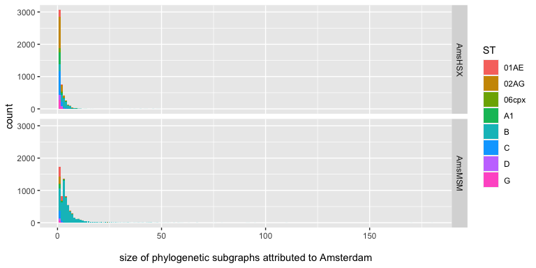

```r
dsubgraphsize <- dsubgraphtaxa[, list(SIZE=length(ID)), by=c('ST','REP','SELECT','NAME')]
dsubgraphsize[, SINGLETON:= as.character(factor(SIZE==1, levels=c(TRUE,FALSE), labels=c('subgraph size 1','subgraph size >1')))]
ggplot(subset(dsubgraphsize, SELECT!='Ams'), aes(x=SIZE, fill=ST)) +
        geom_bar() +
        facet_grid(SELECT~.) +
        labs(x='\nsize of phylogenetic subgraphs attributed to Amsterdam')
```

## **Sample size for phylodynamic analysis of HIV spread in Amsterdam**

Next, let us have a look at how individuals are in subtrees are of size 1 and size >1.

```r
#   number of individuals in subgraphs of size == 1 or size > 1
dsubgraphind <- dsubgraphsize[, list(N_INDIVIDUALS=sum(SIZE)), by=c('REP','ST','SELECT','SINGLETON')]
dsubgraphind <- dcast.data.table(dsubgraphind, REP+ST+SINGLETON~SELECT,value.var='N_INDIVIDUALS')
dsubgraphind[1:14]
```

```
#>     REP    ST        SINGLETON  Ams AmsHSX AmsMSM
#>  1: 000  01AE  subgraph size 1   46     18     26
#>  2: 000  01AE subgraph size >1   61      9     47
#>  3: 000  02AG  subgraph size 1   92     89     16
#>  4: 000  02AG subgraph size >1  186     79     45
#>  5: 000 06cpx  subgraph size 1   16     11      2
#>  6: 000 06cpx subgraph size >1   20     16     NA
#>  7: 000    A1  subgraph size 1   51     34      9
#>  8: 000    A1 subgraph size >1   71     24     36
#>  9: 000     B  subgraph size 1   10     11     59
#> 10: 000     B subgraph size >1 3432    392   2749
#> 11: 000     C  subgraph size 1   97     64     23
#> 12: 000     C subgraph size >1   57     41      8
#> 13: 000     D  subgraph size 1   17     13      5
#> 14: 000     D subgraph size >1   13      8     NA
```

The number of subgraphs of size >1 differ by subtype according to the trasnsmission group (HSX/MSM). For example, subtypes 02_AG and C have the most subgraphs of size >1 amongst HSX, but subtype 01_AE has many more subgraphs of size >1 amongst MSM.

## **Empirical analysis on group-mixing within subgraphs**

To quantify the extent of mixing across certain population groups, we first select just those subgraphs of size >1:

```r
#   number of individuals in subgraphs of size == 1 or size > 1
tmp <- subset(dsubgraphsize, SIZE>1, c(ST, REP, SELECT, NAME))
dsubgraphtaxa2 <- merge(dsubgraphtaxa, tmp, by=c('ST','REP','SELECT','NAME'))
```

### **Place of birth**

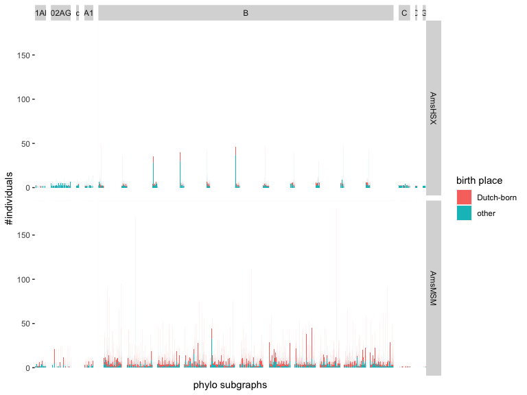

```r
dsubgraphtaxa2[, DUMMY:= as.character(factor(BIRTH_COUNTRY=='Netherlands',levels=c(TRUE,FALSE),labels=c('Dutch-born','other')))]
dcnt <- dsubgraphtaxa2[, list(N= length(ID)), by=c('FULL_NAME','SELECT','ST','DUMMY')]
tmp <- dsubgraphtaxa2[, list(TOTAL= length(ID)), by=c('FULL_NAME','SELECT','ST')]
dcnt <- merge(dcnt, tmp, by=c('FULL_NAME','SELECT','ST'))
ggplot(subset(dcnt, SELECT!='Ams'), aes(x=FULL_NAME, y=N, fill=DUMMY)) +
  geom_bar(stat='identity') +
  labs(y='#individuals',x='phylo subgraphs',fill='birth place') +
  theme(axis.text.x=element_blank(), axis.ticks.x=element_blank()) +
  facet_grid(SELECT~ST, scale='free_x', space='free_x')
```

To make things a bit clearer we can also plot the number of subgraphs which are composed of >=75% Dutch-born individuals, >=75% of individuals born outside of the Netherlands and otherwise mixed:

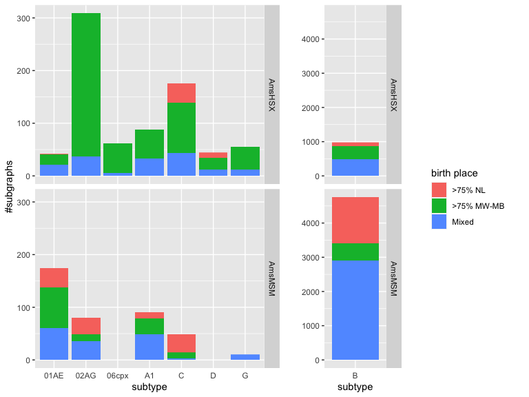

```r
dcnt <- dsubgraphtaxa2[, list(N= length(ID)), by=c('FULL_NAME','REP','SELECT','ST','DUMMY')]
tmp <- dsubgraphtaxa2[, list(TOTAL= length(ID)), by=c('FULL_NAME','REP','SELECT','ST')]
dcnt <- merge(dcnt, tmp, by=c('FULL_NAME','REP','SELECT','ST'))
dcnt$PROP <- dcnt$N/dcnt$TOTAL
bp <- dcnt[, list(N75= length(FULL_NAME[PROP>=0.75])), by=c('SELECT','REP','ST','DUMMY')]
nsubgraphs <- dsubgraphtaxa2[, list(SIZE=length(unique(NAME))), by=c('REP','ST','SELECT')]
bp <- merge(bp,nsubgraphs, by=c('REP','ST','SELECT'))
mixed <- bp[, list(Mixed= SIZE-sum(N75)), by=c('REP','ST','SELECT')]
bp <- spread(bp, DUMMY, N75)
bp <- merge(bp,mixed,by=c('REP','ST','SELECT'))
bp <- unique(bp)
bp <- melt(bp, id.vars=c('REP', 'ST', 'SELECT', 'SIZE'))
bp$bpp <- factor(bp$variable, levels=c('Dutch-born','other','Mixed'),labels=c(">75% NL", ">75% MW-MB", "Mixed"))
nonbl <- ggplot(subset(bp, SELECT!='Ams' & ST!='B'), aes(x=ST, y=value, fill=bpp)) +
  geom_bar(stat='identity') +
  labs(y='#subgraphs',x='subtype',fill='birth place') +
  theme(axis.ticks.x=element_blank()) +
  facet_grid(SELECT~., scale='free_x', space='free_x')
legend <- get_legend(nonbl)
nonb <- ggplot(subset(bp, SELECT!='Ams' & ST!='B'), aes(x=ST, y=value, fill=bpp)) +
  geom_bar(stat='identity') +
  labs(y='#subgraphs',x='subtype',fill='birth place') +
  theme(axis.ticks.x=element_blank(),legend.position="none") +
  facet_grid(SELECT~., scale='free_x', space='free_x')
b <- ggplot(subset(bp, SELECT!='Ams' & ST=='B'), aes(x=ST, y=value, fill=bpp)) +
  geom_bar(stat='identity') +
  labs(y='',x='subtype',fill='birth place') +
  theme(axis.ticks.x=element_blank(),legend.position="none") +
  facet_grid(SELECT~., scale='free_x', space='free_x')
grid.arrange(nonb, b,
                      legend,
                      ncol = 3, widths=c(3.5, 1.5, 1.5))
```

```r
tmp <- dcnt[, list(R= sum( (N/TOTAL)^2), PMAX= max(N/TOTAL) ), by=c('FULL_NAME','SELECT','ST')]
tmp[, list(R_AVG=mean(R), PMAX_AVG=mean(PMAX)), by=c('SELECT')]
```

```
#>    SELECT     R_AVG  PMAX_AVG
#> 1: AmsHSX 0.7838566 0.8186289
#> 2: AmsMSM 0.6593282 0.7246854
#> 3:    Ams 0.6853062 0.7402766
```

The results suggest that

- Amongst HSX, there appear to be more indivuduals born outside of the NL than Dutch-born, with not much mixing, and subgraphs are generally quite small (many of size 2). There appears to be more mixing of groups for subtypes C and D, but subgraphs are still small (size 2/3)
- There are many more Dutch-born individuals in the subgraphs for MSM than foreign-born individuals, with some mixing

### **Place of birth, geographic region**

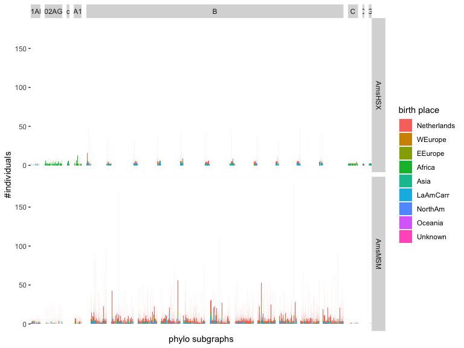

```r
dsubgraphtaxa2$LOC_BIRTH[dsubgraphtaxa2$BIRTH_COUNTRY=='Netherlands'] <- dsubgraphtaxa2$BIRTH_COUNTRY[dsubgraphtaxa2$BIRTH_COUNTRY=='Netherlands']
dsubgraphtaxa2[, DUMMY:= factor(LOC_BIRTH, levels=c('Netherlands','WEurope','EEurope','Africa','Asia','LaAmCarr','NorthAm','Oceania','Unknown'),labels=c('Netherlands','WEurope','EEurope','Africa','Asia','LaAmCarr','NorthAm','Oceania','Unknown'))]
dcnt <- dsubgraphtaxa2[, list(N= length(ID)), by=c('FULL_NAME','SELECT','ST','DUMMY')]
tmp <- dsubgraphtaxa2[, list(TOTAL= length(ID)), by=c('FULL_NAME','SELECT','ST')]
dcnt <- merge(dcnt, tmp, by=c('FULL_NAME','SELECT','ST'))
ggplot(subset(dcnt, SELECT!='Ams'), aes(x=FULL_NAME, y=N, fill=DUMMY)) +
  geom_bar(stat='identity') +
  labs(y='#individuals',x='phylo subgraphs',fill='birth place') +
  theme(axis.text.x=element_blank(), axis.ticks.x=element_blank()) +
  facet_grid(SELECT~ST, scale='free_x', space='free_x')
```

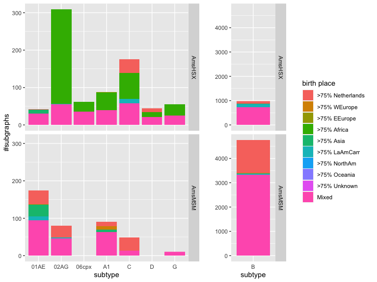

```r
dcnt <- dsubgraphtaxa2[, list(N= length(ID)), by=c('FULL_NAME','REP','SELECT','ST','DUMMY')]
tmp <- dsubgraphtaxa2[, list(TOTAL= length(ID)), by=c('FULL_NAME','REP','SELECT','ST')]
dcnt <- merge(dcnt, tmp, by=c('FULL_NAME','REP','SELECT','ST'))
dcnt$PROP <- dcnt$N/dcnt$TOTAL
bp <- dcnt[, list(N75= length(FULL_NAME[PROP>=0.75])), by=c('SELECT','REP','ST','DUMMY')]
nsubgraphs <- dsubgraphtaxa2[, list(SIZE=length(unique(NAME))), by=c('REP','ST','SELECT')]
bp <- merge(bp,nsubgraphs, by=c('REP','ST','SELECT'))
mixed <- bp[, list(Mixed= SIZE-sum(N75)), by=c('REP','ST','SELECT')]
bp <- spread(bp, DUMMY, N75)
bp <- merge(bp,mixed,by=c('REP','ST','SELECT'))
bp <- unique(bp)
bp <- melt(bp, id.vars=c('REP', 'ST', 'SELECT', 'SIZE'))

bp$bpp <- factor(bp$variable, levels=c('Netherlands','WEurope','EEurope','Africa','Asia','LaAmCarr','NorthAm','Oceania','Unknown','Mixed'),labels=c('>75% Netherlands','>75% WEurope','>75% EEurope','>75% Africa','>75% Asia','>75% LaAmCarr','>75% NorthAm','>75% Oceania','>75% Unknown','Mixed'))
nonbl <-  ggplot(subset(bp, SELECT!='Ams' & ST!='B'), aes(x=ST, y=value, fill=bpp)) +
  geom_bar(stat='identity') +
  labs(y='#subgraphs',x='subtype',fill='birth place') +
  theme(axis.ticks.x=element_blank()) +
  facet_grid(SELECT~., scale='free_x', space='free_x')
legend <- get_legend(nonbl)
nonb <- ggplot(subset(bp, SELECT!='Ams' & ST!='B'), aes(x=ST, y=value, fill=bpp)) +
  geom_bar(stat='identity') +
  labs(y='#subgraphs',x='subtype',fill='birth place') +
  theme(axis.ticks.x=element_blank(),legend.position="none") +
  facet_grid(SELECT~., scale='free_x', space='free_x')
b <-   ggplot(subset(bp, SELECT!='Ams' & ST=='B'), aes(x=ST, y=value, fill=bpp)) +
  geom_bar(stat='identity') +
  labs(y='',x='subtype',fill='birth place') +
  theme(axis.ticks.x=element_blank(),legend.position="none") +
  facet_grid(SELECT~., scale='free_x', space='free_x')
grid.arrange(nonb, b,
                           legend,
                           ncol = 3, widths=c(3.5, 1.5, 1.5))
```

```r
tmp <- dcnt[, list(R= sum( (N/TOTAL)^2), PMAX= max(N/TOTAL) ), by=c('FULL_NAME','SELECT','ST')]
tmp[, list(R_AVG=mean(R), PMAX_AVG=mean(PMAX)), by=c('SELECT')]
```

```
#>    SELECT     R_AVG  PMAX_AVG
#> 1: AmsHSX 0.6710713 0.7130908
#> 2: AmsMSM 0.5655848 0.6494109
#> 3:    Ams 0.5868850 0.6618952
```

- There appears to be much more evidence of mixing of birth regions amongst MSM than HSX, and subgraphs are generally larger for subtypes 01_AE, 01_AG, A1

### **Age group**

Next, we consider age brackets for comparison:

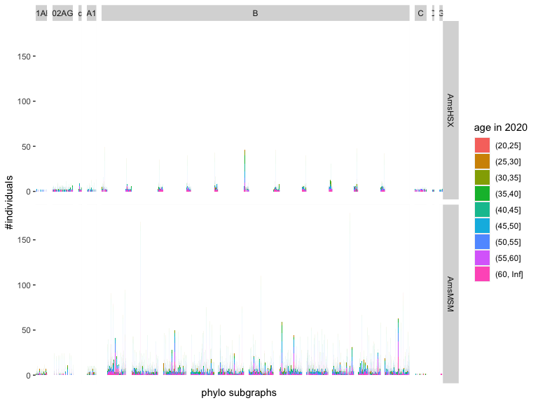

```r
dsubgraphtaxa2[, DUMMY:= AGE2020]
dcnt <- dsubgraphtaxa2[, list(N= length(ID)), by=c('FULL_NAME','SELECT','ST','DUMMY')]
tmp <- dsubgraphtaxa2[, list(TOTAL= length(ID)), by=c('FULL_NAME','SELECT','ST')]
dcnt <- merge(dcnt, tmp, by=c('FULL_NAME','SELECT','ST'))
ggplot(subset(dcnt, SELECT!='Ams'), aes(x=FULL_NAME, y=N, fill=DUMMY)) +
  geom_bar(stat='identity') +
  labs(y='#individuals',x='phylo subgraphs',fill='age in 2020') +
  theme(axis.text.x=element_blank(), axis.ticks.x=element_blank()) +
  facet_grid(SELECT~ST, scale='free_x', space='free_x')
```

```r
tmp <- dcnt[, list(R= sum( (N/TOTAL)^2), PMAX= max(N/TOTAL) ), by=c('FULL_NAME','SELECT','ST')]
tmp[, list(R_AVG=mean(R), PMAX_AVG=mean(PMAX)), by=c('SELECT')]
```

```
#>    SELECT     R_AVG  PMAX_AVG
#> 1: AmsHSX 0.4945599 0.5383538
#> 2: AmsMSM 0.3911549 0.4578233
#> 3:    Ams 0.4126593 0.4727299
```